# Analysis

> Quid pro quo? An explanation for why partisan alignment pays off

# Data

The unit of analysis in our dataset is the pair municipality $i$ ministry $j$ observerd in year $t$. In total, this structure comprises `740112` observations, with `5565` unique municipalities and `17` unique ministries.

## Proposals

In our sample, municipalities requested on average `547744.19` Brazilian reais (adjusted for inflation) between 2009 and 2016, or `40` reais per capita. There is a total of `483532` proposals that were submited by municipalities to the Federal Government requesting transfers. Finally, of all municipality-ministry-year units, `571369` did not submit any proposals, `77.2%` of all units.

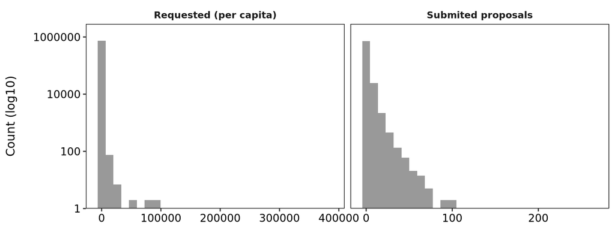

## Ministries

The plot below the distribution of submited proposals by ministries they targeted.

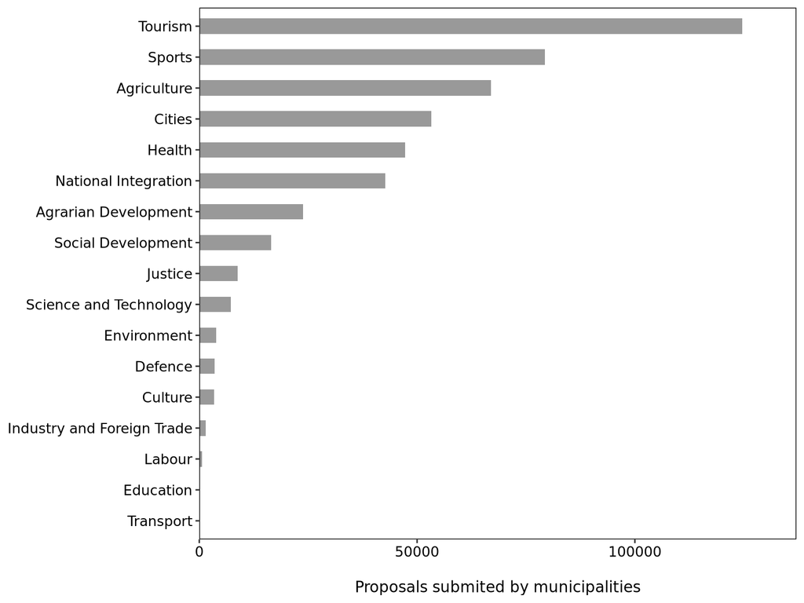

# Partisan Aligment

## Difference in means

### Considering non-responders as zero

Below we estimate differences in distributive outcomes between aligned and non-aligned municipality-ministry pairs. In particular, for values we do not observe in variables such as `Proportion of rejected proposals` (i.e., we only observe rejection status for municipalities that submited proposals) we input the value of zero. In this way, we deal with attrition by assuming non-submission as an inferior type of submission.

|  | Non-aligned (N=655444) Mean | Non-aligned (N=655444) Std. Dev. | Aligned (N=81336) Mean | Aligned (N=81336) Std. Dev. | Diff. in Means | Std. Error |
| --- | --- | --- | --- | --- | --- | --- |
| Submited proposals | 0.62 | 2.01 | 0.94 | 2.48 | 0.32 | 0.01 |
| Transfers per capita | 4.96 | 39.88 | 8.86 | 72.77 | 3.90 | 0.26 |
| N convenios | 0.10 | 0.43 | 0.19 | 0.61 | 0.09 | 0.00 |
| Prop. rejected proposals | 0.03 | 0.15 | 0.03 | 0.16 | 0.00 | 0.00 |
| Avg. attachments | 0.99 | 3.51 | 1.66 | 4.41 | 0.67 | 0.02 |
| Avg. object word count | 3.85 | 16.21 | 5.22 | 18.18 | 1.37 | 0.07 |
| Avg. justification word count | 62.29 | 146.10 | 96.29 | 180.87 | 33.99 | 0.66 |
| Prop. ata posse | 0.36 | 2.28 | 0.52 | 2.57 | 0.16 | 0.01 |
| Prop. plano de trabalho | 0.31 | 2.05 | 0.53 | 2.49 | 0.22 | 0.01 |
| Prop. cotações | 0.25 | 1.91 | 0.41 | 2.30 | 0.16 | 0.01 |
| Prop. cronograma | 0.07 | 1.00 | 0.10 | 1.12 | 0.03 | 0.00 |
| Avg. payments to providers | 0.36 | 4.31 | 0.64 | 5.23 | 0.28 | 0.02 |
| Avg. number of providers | 0.10 | 0.90 | 0.19 | 1.09 | 0.09 | 0.00 |
| Avg. providers’ time in operation | 0.78 | 3.88 | 1.53 | 5.52 | 0.75 | 0.02 |
| Avg. diárias payments | 0.00 | 0.00 | 0.00 | 0.00 | 0.00 | 0.00 |
| Provider donnor (dummy) | 0.00 | 0.02 | 0.00 | 0.03 | 0.00 | 0.00 |

### Subsample

In this part, we reestimate the difference in means using a sub-sample of our data that contains a smaller proportion of non-observed outcomes. To that end, we subseted ou sample to include only the following ministries: “National Integration”, “Health”, “Cities”, “Agriculture”, “Tourism”, “Sports”. In addition, we filtered out municipalities with fewer than 30k inhabitants. After these procedures, our resulting sample have `50028` observations, with `21895` that did not submit any proposals, `43.8%`.

|  | Non-aligned (N=43051) Mean | Non-aligned (N=43051) Std. Dev. | Aligned (N=6839) Mean | Aligned (N=6839) Std. Dev. | Diff. in Means | Std. Error |
| --- | --- | --- | --- | --- | --- | --- |
| Submited proposals | 2.05 | 3.99 | 2.36 | 4.62 | 0.31 | 0.06 |
| Transfers per capita | 5.18 | 32.05 | 6.44 | 32.16 | 1.26 | 0.42 |
| N convenios | 0.38 | 0.86 | 0.49 | 1.01 | 0.11 | 0.01 |
| Prop. rejected proposals | 0.05 | 0.17 | 0.04 | 0.16 | -0.00 | 0.00 |
| Avg. attachments | 2.87 | 5.39 | 3.44 | 5.80 | 0.57 | 0.07 |
| Avg. object word count | 9.88 | 22.17 | 9.84 | 21.80 | -0.04 | 0.28 |
| Avg. justification word count | 160.44 | 196.73 | 183.44 | 214.25 | 23.00 | 2.76 |
| Prop. ata posse | 1.14 | 4.01 | 1.19 | 3.68 | 0.06 | 0.05 |
| Prop. plano de trabalho | 0.77 | 3.11 | 0.90 | 3.11 | 0.13 | 0.04 |
| Prop. cotações | 0.60 | 2.89 | 0.64 | 2.61 | 0.04 | 0.03 |
| Prop. cronograma | 0.21 | 1.68 | 0.18 | 1.35 | -0.03 | 0.02 |
| Avg. payments to providers | 1.31 | 5.12 | 1.60 | 6.25 | 0.29 | 0.08 |
| Avg. number of providers | 0.30 | 0.91 | 0.39 | 1.08 | 0.09 | 0.01 |
| Avg. providers’ time in operation | 2.86 | 7.24 | 3.66 | 8.27 | 0.81 | 0.11 |
| Avg. diárias payments | 0.00 | 0.00 | 0.00 | 0.00 | 0.00 | 0.00 |
| Provider donnor (dummy) | 0.00 | 0.06 | 0.00 | 0.07 | 0.00 | 0.00 |

## Difference-in-Differences

### Main variables

|  | Transfers per capita (DiD) | Transfers per capita (DDD) | Submited proposals (DiD) | Submited proposals (DDD) |
| --- | --- | --- | --- | --- |
| Partisan aligment | 1.16* | 1.39** | 0.09*** | 0.12*** |
|  | (0.51) | (0.51) | (0.01) | (0.02) |
| Num.Obs. | 736780 | 736780 | 736780 | 736780 |
| Std.Errors | by: cod_ibge | by: cod_ibge | by: cod_ibge | by: cod_ibge |

### Quality of proposals

|  | Partisan aligment |
| --- | --- |
| Prop. rejected proposals (DiD) | 0.00 [0.00, 0.00]+ |
| Prop. rejected proposals (DDD) | 0.00 [0.00, 0.00]* |
| Avg. attachments (DiD) | 0.15 [0.10, 0.20]*** |
| Avg. attachments (DDD) | 0.15 [0.09, 0.20]*** |
| Avg. object word count (DiD) | 0.17 [−0.05, 0.39] |
| Avg. object word count (DDD) | 0.26 [0.02, 0.49]* |
| Avg. just. word count (DiD) | 2.90 [1.16, 4.63]** |
| Avg. just. word count (DDD) | 4.32 [2.46, 6.18]*** |
| Prop. ata posse (DiD) | 0.05 [0.01, 0.08]** |
| Prop. ata posse (DDD) | 0.04 [0.01, 0.08]* |
| Prop. plano de trabalho (DiD) | 0.05 [0.02, 0.08]*** |
| Prop. plano de trabalho (DDD) | 0.05 [0.02, 0.08]** |
| Prop. cotações (DiD) | 0.03 [0.00, 0.06]* |
| Prop. cotações (DDD) | 0.02 [0.00, 0.05] |
| Prop. cronograma (DiD) | 0.01 [−0.01, 0.02] |
| Prop. cronograma (DDD) | 0.01 [−0.01, 0.02] |

### Quality of providers

|  | Partisan aligment |
| --- | --- |
| Avg. payments to providers (DiD) | 0.08 [0.03, 0.13]** |
| Avg. payments to providers (DDD) | 0.10 [0.05, 0.16]*** |
| Avg. number of providers (DiD) | 0.03 [0.02, 0.04]*** |
| Avg. number of providers (DDD) | 0.04 [0.03, 0.05]*** |
| Avg. providers’ time in operation (DiD) | 0.18 [0.12, 0.24]*** |
| Avg. providers’ time in operation (DDD) | 0.22 [0.15, 0.29]*** |
| At least 1 small company (dummy) (DiD) | 0.01 [0.01, 0.02]*** |
| At least 1 small company (dummy) (DDD) | 0.02 [0.01, 0.02]*** |
| Provider donnor (dummy) (DiD) | 0.00 [0.00, 0.00] |
| Provider donnor (dummy) (DDD) | 0.00 [0.00, 0.00] |